# CFPS data analysis

Lin Wenzheng

2024-11-05

# Research Question

- The effect of parenting motivation on pro-environmental behaviors

# Parenting motivation

- 抚育动机(parenting motivation)，或抚育动机系统(parental care motivational system)，是指一系列旨在照顾脆弱的年幼儿的情感和认知机制(Buckels et al.,2015; Griskevicius & Kenrick, 2013; Li et al., 2019)
- CFPS 2018: qka202

```
## [1] "期望孩子数（个）"
```

- CFPS 2020: qq9013

```
## [1] "照顾孩子时长（小时/天）"
```

# Parenting motivation on pro-environmental behaviors

- 抚育是人类繁衍和生存的重要行为 (Geary 2000; Hill and Hurtado 1996)
- 抚育动机是促发这一行为的内在心理机制 (Buckels et al. 2015; Griskevicius and Kenrick 2013; Kenrick et al. 2010)
- 因此，高抚育动机使个体更关注后代和人类长久福祉，更能规避短视而破坏人类长期利益的行为
- 环保行为试图保障环境的可持续性，维护人类的长期生存环境 (Tian & Liu, 2022)
- 家庭人均水电与能源支出；控制家庭年收入与支出

```r
lapply(df2[, c("fp402","fp403","fp404","fml_count.x")], function(x) attr(x, "label"))
```

```
## $fp402
## [1] "每月水费（元）"
##
## $fp403
## [1] "每月电费（元）"
##
## $fp404
## [1] "每月燃料费（元）"
##
## $fml_count.x
## [1] "加载变量：2018年家庭成员人数"
```

```r
# lapply(df2[, c("finc","finc_est","finc1")], function(x) attr(x, "label"))
# lapply(df2[, c("fexp","fexp_est","fexp1")], function(x) attr(x, "label"))
```

# Correlation matrix

- 由于CFPS数据为家庭调查嵌套数据，相关矩阵使用第二层数据
  - 部分第二层数据（家庭）为第一层数据（个体）aggregate 得到

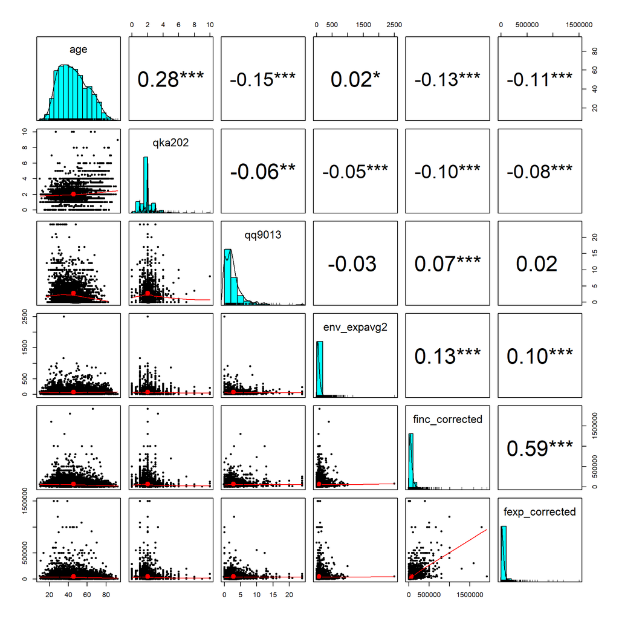

```r
# lapply(df2[, c("qka202","qn6012","finc_corrected","fexp_corrected")], function(x) attr(x, "label"))
pairs.panels(df5[,c(6,8,16,11,13,14)], stars = TRUE)
```

# Data Nesting in Provinces

```r
my.lme0 <- lmer(env_expavg2 ~ (1|provcd18.r),data=df5,REML=F)
ICC_cal <- as.data.frame(VarCorr(my.lme0))
ICC_cal[1,"sdcor"]/ICC_cal[2,"sdcor"]
```

```
## [1] 0.2067446
```

### 自变量：期望孩子数（个；家庭所有成员平均）

```r
my.lme1 <- lmer(env_expavg2 ~ scale(qka202) +scale(age) +scale(finc_corrected)+scale(fexp_corrected)+ (1|provcd18.r),data=df5,REML=F)
summary(my.lme1)
```

```
## Linear mixed model fit by maximum likelihood . t-tests use Satterthwaite's
##   method [lmerModLmerTest]
## Formula: env_expavg2 ~ scale(qka202) + scale(age) + scale(finc_corrected) +
##     scale(fexp_corrected) + (1 | provcd18.r)
##    Data: df5
##
##      AIC      BIC   logLik deviance df.resid
## 110164.8 110214.9 -55075.4 110150.8     9513
##
## Scaled residuals:
##     Min      1Q  Median      3Q     Max
## -2.1466 -0.5068 -0.2331  0.1955 30.5550
##
## Random effects:
##  Groups     Name        Variance Std.Dev.
##  provcd18.r (Intercept)  202.4   14.23
##  Residual               6159.1   78.48
## Number of obs: 9520, groups:  provcd18.r, 55
##
## Fixed effects:
##                        Estimate Std. Error        df t value Pr(>|t|)
## (Intercept)             77.2574     2.6950   39.1339  28.667  < 2e-16 ***
## scale(qka202)           -3.5126     0.8928 9423.0613  -3.935 8.40e-05 ***
## scale(age)               3.6627     0.8912 9454.7481   4.110 3.99e-05 ***
## scale(finc_corrected)    7.2911     1.0390 9508.1946   7.017 2.42e-12 ***
## scale(fexp_corrected)    2.8007     1.0014 9504.5029   2.797  0.00517 **
## ---
## Signif. codes:  0 '***' 0.001 '**' 0.01 '*' 0.05 '.' 0.1 ' ' 1
##
## Correlation of Fixed Effects:
##             (Intr) s(202) scl(g) scl(fn_)
## scal(qk202) -0.006
## scale(age)   0.031 -0.319
## scl(fnc_cr) -0.001  0.039  0.080
## scl(fxp_cr) -0.004  0.004  0.046 -0.530
```

- 期望孩子数显著负向预测了家庭水电能源支出（2018）

```r
my.lme2 <- lmer(env_expavg2_20 ~ scale(qka202) +scale(age) +scale(finc_corrected_20)+scale(fexp_corrected_20)+scale(finc_corrected)+scale(fexp_corrected)+ (1|provcd18.r),data=df6,REML=F)
summary(my.lme2)
```

```
## Linear mixed model fit by maximum likelihood . t-tests use Satterthwaite's
##   method [lmerModLmerTest]
## Formula:
## env_expavg2_20 ~ scale(qka202) + scale(age) + scale(finc_corrected_20) +
##     scale(fexp_corrected_20) + scale(finc_corrected) + scale(fexp_corrected) +
##     (1 | provcd18.r)
##    Data: df6
##
##      AIC      BIC   logLik deviance df.resid
## 110801.3 110865.7 -55391.7 110783.3     9477
##
## Scaled residuals:
##     Min      1Q  Median      3Q     Max
## -2.1013 -0.5167 -0.2491  0.2039 18.4463
##
## Random effects:
##  Groups     Name        Variance Std.Dev.
##  provcd18.r (Intercept)  318.1   17.84
##  Residual               6855.1   82.80
## Number of obs: 9486, groups:  provcd18.r, 55
##
## Fixed effects:
##                           Estimate Std. Error        df t value Pr(>|t|)
## (Intercept)                78.9804     3.2305   38.6216  24.449  < 2e-16 ***
## scale(qka202)              -2.5559     0.9401 9447.0779  -2.719  0.00657 **
## scale(age)                  4.7265     0.9425 9446.5514   5.015 5.40e-07 ***
## scale(finc_corrected_20)    1.5163     1.0602 9478.4710   1.430  0.15271
## scale(fexp_corrected_20)    2.3765     0.9823 9456.6049   2.419  0.01557 *
## scale(finc_corrected)       5.3642     1.1441 9482.3137   4.689 2.79e-06 ***
## scale(fexp_corrected)       1.4582     1.0800 9457.8142   1.350  0.17699
## ---
## Signif. codes:  0 '***' 0.001 '**' 0.01 '*' 0.05 '.' 0.1 ' ' 1
##
## Correlation of Fixed Effects:
##             (Intr) s(202) scl(g) scl(fn__20) scl(fx__20) scl(fn_)
## scal(qk202) -0.006
## scale(age)   0.035 -0.310
## scl(fn__20) -0.002  0.032  0.069
## scl(fx__20)  0.000 -0.007  0.039 -0.368
## scl(fnc_cr)  0.000  0.021  0.043 -0.269      -0.075
## scl(fxp_cr) -0.001  0.001  0.031 -0.033      -0.088      -0.491
```

- 滞后模型：期望孩子数显著负向预测了家庭水电能源支出（2020）

### 自变量：照顾孩子时长（小时/天；家庭所有成员平均）

```r
my.lme3 <- lmer(env_expavg2 ~ scale(qq9013) +scale(age) +scale(finc_corrected)+scale(fexp_corrected)+ (1|provcd20.r),data=df5_20,REML=F)
summary(my.lme3)
```

```
## Linear mixed model fit by maximum likelihood . t-tests use Satterthwaite's
##   method [lmerModLmerTest]
## Formula: env_expavg2 ~ scale(qq9013) + scale(age) + scale(finc_corrected) +
##     scale(fexp_corrected) + (1 | provcd20.r)
##    Data: df5_20
##
##      AIC      BIC   logLik deviance df.resid
##  21510.9  21549.5 -10748.5  21496.9     1822
##
## Scaled residuals:
##     Min      1Q  Median      3Q     Max
## -1.7484 -0.5052 -0.2361  0.1916 15.0183
##
## Random effects:
##  Groups     Name        Variance Std.Dev.
##  provcd20.r (Intercept)  152.1   12.33
##  Residual               7365.5   85.82
## Number of obs: 1829, groups:  provcd20.r, 39
##
## Fixed effects:
##                       Estimate Std. Error       df t value Pr(>|t|)
## (Intercept)             81.714      3.498   35.596  23.360  < 2e-16 ***
## scale(qq9013)           -5.752      2.061 1828.203  -2.791  0.00531 **
## scale(age)              -3.321      2.513 1828.781  -1.321  0.18655
## scale(finc_corrected)    3.864      3.467 1806.839   1.114  0.26528
## scale(fexp_corrected)    4.500      3.199 1829.000   1.407  0.15966
## ---
## Signif. codes:  0 '***' 0.001 '**' 0.01 '*' 0.05 '.' 0.1 ' ' 1
##
## Correlation of Fixed Effects:
##             (Intr) s(9013 scl(g) scl(fn_)
## scl(qq9013)  0.046
## scale(age)   0.172  0.200
## scl(fnc_cr) -0.016 -0.005  0.122
## scl(fxp_cr) -0.017 -0.041 -0.010 -0.730
```

- 照顾孩子时长显著负向预测了家庭水电能源支出（2020）

# 生育价值观降维

### 生育价值观

```r
KMO(df_qme)
```

```
## Kaiser-Meyer-Olkin factor adequacy
## Call: KMO(r = df_qme)
## Overall MSA =  0.87
## MSA for each item =
## qme201 qme202 qme203 qme204 qme205 qme206 qme207 qme208 qme209
##   0.84   0.82   0.84   0.88   0.85   0.86   0.91   0.89   0.90
```

```r
#scree(df_qme, pc=F)
```

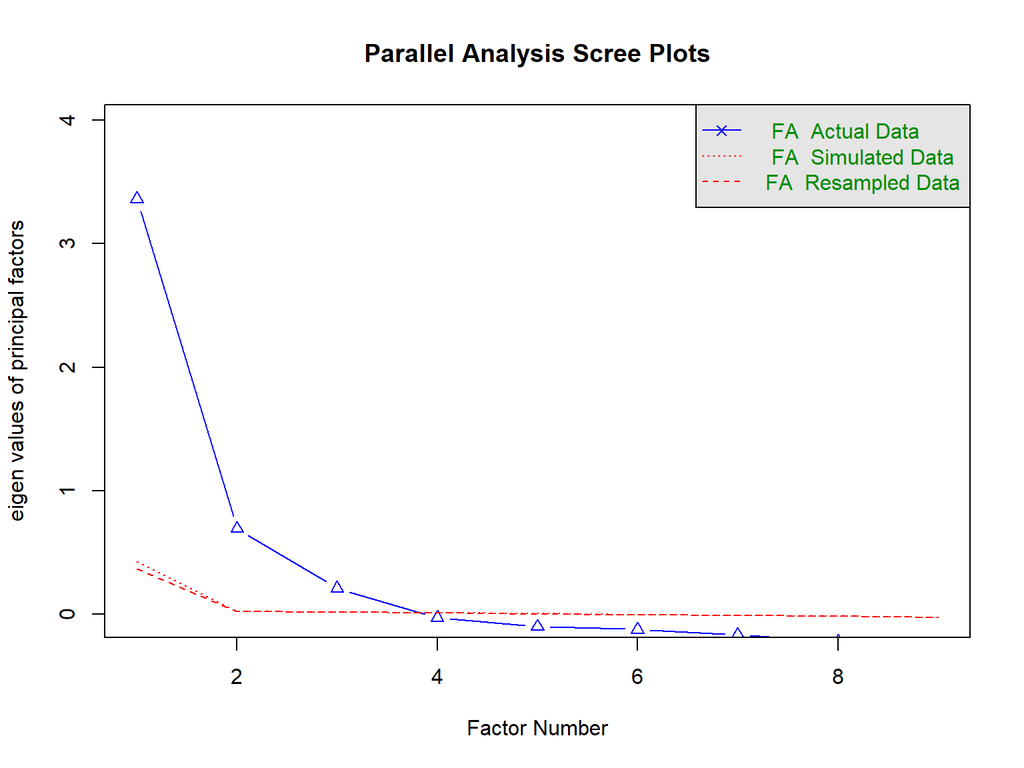

```
## Parallel analysis suggests that the number of factors =  3  and the number of components =  NA
```

```r
fa.parallel(df_qme, fa="fa")
```

```r
fa.fit <- psych::fa(r = cor(df_qme), nfactors = 3, fm = "ml", rotate = "promax")
fa.fit
```

```
## Factor Analysis using method =  ml
## Call: psych::fa(r = cor(df_qme), nfactors = 3, rotate = "promax", fm = "ml")
## Standardized loadings (pattern matrix) based upon correlation matrix
##          ML1   ML2   ML3   h2   u2 com
## qme201  0.03  0.66 -0.02 0.44 0.56 1.0
## qme202  0.00  0.75 -0.02 0.55 0.45 1.0
## qme203 -0.02  0.65  0.05 0.46 0.54 1.0
## qme204  0.73  0.03 -0.01 0.54 0.46 1.0
## qme205  0.84  0.02 -0.06 0.64 0.36 1.0
## qme206  0.69 -0.05  0.15 0.61 0.39 1.1
## qme207  0.17  0.03  0.54 0.48 0.52 1.2
## qme208  0.04 -0.08  0.78 0.58 0.42 1.0
## qme209 -0.05  0.11  0.63 0.45 0.55 1.1
##
##                        ML1  ML2  ML3
## SS loadings           1.84 1.46 1.44
## Proportion Var        0.20 0.16 0.16
## Cumulative Var        0.20 0.37 0.53
## Proportion Explained  0.39 0.31 0.30
## Cumulative Proportion 0.39 0.70 1.00
##
##  With factor correlations of
##      ML1  ML2  ML3
## ML1 1.00 0.42 0.71
## ML2 0.42 1.00 0.59
## ML3 0.71 0.59 1.00
##
## Mean item complexity =  1.1
## Test of the hypothesis that 3 factors are sufficient.
##
## df null model =  36  with the objective function =  3.04
## df of  the model are 12  and the objective function was  0.01
##
## The root mean square of the residuals (RMSR) is  0.01
## The df corrected root mean square of the residuals is  0.01
##
## Fit based upon off diagonal values = 1
## Measures of factor score adequacy
##                                                    ML1  ML2  ML3
## Correlation of (regression) scores with factors   0.92 0.87 0.89
## Multiple R square of scores with factors          0.84 0.76 0.80
## Minimum correlation of possible factor scores     0.68 0.53 0.60
```

```r
lapply(df1_person20[, qme_items], function(x) attr(x, "label"))
```

```
## $qme201
## [1] "为了年老时有人帮助"
##
## $qme202
## [1] "为了延续家族香火"
##
## $qme203
## [1] "为从经济上帮助家庭"
##
## $qme204
## [1] "为看孩子长大的喜悦"
##
## $qme205
## [1] "为子女在身边的快乐"
##
## $qme206
## [1] "为感受有宝宝的喜悦"
##
## $qme207
## [1] "为使家庭更重要"
##
## $qme208
## [1] "为增强责任心"
##
## $qme209
## [1] "为增加亲属联系"
```

- qme201~qme203：家庭功能动机/Collective continuity (of family)
- qme204~qme206：情绪价值动机/Affective values (of child)
- qme207~qme209：社会责任动机/Family relative value

### 生育价值观预测家庭水电能源支出

```r
my.lme4 <- lmer(env_expavg2 ~  scale(age)  + scale(finc_corrected) +scale(fexp_corrected)+scale(fermotiv1)+scale(fermotiv2)+scale(fermotiv3) +(1|provcd20.r) ,data=df5_20,REML=F)
summary(my.lme4)
```

```
## Linear mixed model fit by maximum likelihood . t-tests use Satterthwaite's
##   method [lmerModLmerTest]
## Formula:
## env_expavg2 ~ scale(age) + scale(finc_corrected) + scale(fexp_corrected) +
##     scale(fermotiv1) + scale(fermotiv2) + scale(fermotiv3) +
##     (1 | provcd20.r)
##    Data: df5_20
##
##      AIC      BIC   logLik deviance df.resid
##  71455.4  71515.6 -35718.7  71437.4     5946
##
## Scaled residuals:
##     Min      1Q  Median      3Q     Max
## -1.5871 -0.5155 -0.2433  0.2249 16.4161
##
## Random effects:
##  Groups     Name        Variance Std.Dev.
##  provcd20.r (Intercept)  315.6   17.77
##  Residual               9410.7   97.01
## Number of obs: 5955, groups:  provcd20.r, 48
##
## Fixed effects:
##                       Estimate Std. Error       df t value Pr(>|t|)
## (Intercept)             95.497      3.679   32.753  25.954  < 2e-16 ***
## scale(age)               2.106      1.413 5939.203   1.490 0.136230
## scale(finc_corrected)    3.773      1.837 5934.717   2.054 0.040063 *
## scale(fexp_corrected)    2.889      1.525 5942.093   1.894 0.058311 .
## scale(fermotiv1)        -5.830      1.567 5950.849  -3.720 0.000201 ***
## scale(fermotiv2)        -1.311      1.598 5941.392  -0.820 0.412087
## scale(fermotiv3)         1.945      1.698 5944.189   1.146 0.252045
## ---
## Signif. codes:  0 '***' 0.001 '**' 0.01 '*' 0.05 '.' 0.1 ' ' 1
##
## Correlation of Fixed Effects:
##             (Intr) scl(g) scl(fn_) scl(fx_) scl(1) scl(2)
## scale(age)  -0.021
## scl(fnc_cr) -0.015  0.133
## scl(fxp_cr) -0.010  0.023 -0.537
## scl(frmtv1)  0.013 -0.330  0.098    0.035
## scl(frmtv2)  0.000  0.093 -0.049   -0.006   -0.097
## scl(frmtv3) -0.003 -0.058  0.005    0.008   -0.308 -0.537
```

- 降维后的养育动机量表发现，仅家庭功能动机负向预测了水电能源支出
  - 一定程度上体现了抚育动机中关注集体自我连续性而体现出的长计远虑属性

```r
lapply(df1_person20[, qme_items[c(1:3)]], function(x) attr(x, "label"))
```

```
## $qme201
## [1] "为了年老时有人帮助"
##
## $qme202
## [1] "为了延续家族香火"
##
## $qme203
## [1] "为从经济上帮助家庭"
```

### 生育价值观对生育动机的调节作用

```r
my.lme3 <- lmer(env_expavg2_20 ~ qka202+age+finc_corrected+fexp_corrected+fermotiv1+fermotiv2+fermotiv3+qka202:fermotiv1+qka202:fermotiv2+qka202:fermotiv3 +(1|provcd18.r) ,data=df6,REML=F)
summary(my.lme3)
```

```
## Linear mixed model fit by maximum likelihood . t-tests use Satterthwaite's
##   method [lmerModLmerTest]
## Formula: env_expavg2_20 ~ qka202 + age + finc_corrected + fexp_corrected +
##     fermotiv1 + fermotiv2 + fermotiv3 + qka202:fermotiv1 + qka202:fermotiv2 +
##     qka202:fermotiv3 + (1 | provcd18.r)
##    Data: df6
##
##      AIC      BIC   logLik deviance df.resid
## 108024.0 108116.7 -53999.0 107998.0     9240
##
## Scaled residuals:
##     Min      1Q  Median      3Q     Max
## -2.2803 -0.5129 -0.2428  0.1992 18.5844
##
## Random effects:
##  Groups     Name        Variance Std.Dev.
##  provcd18.r (Intercept)  300.1   17.32
##  Residual               6808.1   82.51
## Number of obs: 9253, groups:  provcd18.r, 55
##
## Fixed effects:
##                    Estimate Std. Error         df t value Pr(>|t|)
## (Intercept)       1.163e+02  2.083e+01  8.448e+03   5.583 2.44e-08 ***
## qka202           -1.514e+01  9.486e+00  9.231e+03  -1.596  0.11041
## age               4.351e-01  6.893e-02  9.197e+03   6.312 2.88e-10 ***
## finc_corrected    7.363e-05  1.376e-05  9.251e+03   5.353 8.86e-08 ***
## fexp_corrected    2.473e-05  1.579e-05  9.227e+03   1.566  0.11732
## fermotiv1        -1.486e+01  5.498e+00  9.236e+03  -2.703  0.00689 **
## fermotiv2         7.468e+00  8.426e+00  9.226e+03   0.886  0.37552
## fermotiv3        -1.220e+01  8.600e+00  9.224e+03  -1.419  0.15600
## qka202:fermotiv1  2.731e+00  2.699e+00  9.229e+03   1.012  0.31161
## qka202:fermotiv2 -6.070e+00  4.053e+00  9.225e+03  -1.498  0.13422
## qka202:fermotiv3  7.520e+00  4.104e+00  9.223e+03   1.833  0.06690 .
## ---
## Signif. codes:  0 '***' 0.001 '**' 0.01 '*' 0.05 '.' 0.1 ' ' 1
##
## Correlation of Fixed Effects:
##             (Intr) qka202 age    fnc_cr fxp_cr frmtv1 frmtv2 frmtv3 q202:1
## qka202      -0.893
## age         -0.055 -0.038
## finc_crrctd -0.045 -0.005  0.052
## fexp_crrctd -0.031  0.003  0.025 -0.545
## fermotiv1   -0.149  0.157 -0.052  0.034  0.016
## fermotiv2   -0.421  0.377  0.003  0.001 -0.012 -0.128
## fermotiv3   -0.239  0.218 -0.020 -0.015  0.015 -0.351 -0.596
## qk202:frmt1  0.142 -0.180 -0.040  0.001  0.002 -0.920  0.138  0.312
## qk202:frmt2  0.360 -0.386  0.031 -0.009  0.008  0.134 -0.930  0.566 -0.163
## qk202:frmt3  0.207 -0.228 -0.005  0.016 -0.012  0.322  0.571 -0.929 -0.328
##             q202:2
## qka202
## age
## finc_crrctd
## fexp_crrctd
## fermotiv1
## fermotiv2
## fermotiv3
## qk202:frmt1
## qk202:frmt2
## qk202:frmt3 -0.619
## fit warnings:
## Some predictor variables are on very different scales: consider rescaling
```

```r
#my.lme3 <- lmer(qme202_20 ~ scale(qka202,scale=F) + scale(age, scale=F) + scale(qme202_20, scale=F) + scale(finc_corrected, scale=F) +scale(fexp_corrected,scale=F)+scale(fermotiv1,scale=F)+(1|provcd18.x) ,data=df5,REML=F)
```

# 城乡

```r
attr(df1_person18$urban18, "label")
```

```
## [1] "基于国家统计局资料的城乡分类"
```

```r
attr(df1_person18$urban18, "labels")
```

```
## 无法判断     缺失   不适用 拒绝回答   不知道     乡村     城镇
##      -10       -9       -8       -2       -1        0        1
```

### 18年：城乡的调节作用

```r
my.lme4 <- lmer(env_expavg2 ~ qka202 +age +finc_corrected+fexp_corrected+urban18.y +qka202:urban18.y +(1|provcd18.r) ,data=df6,REML=F)
summary(my.lme4)
```

```
## Linear mixed model fit by maximum likelihood . t-tests use Satterthwaite's
##   method [lmerModLmerTest]
## Formula: env_expavg2 ~ qka202 + age + finc_corrected + fexp_corrected +
##     urban18.y + qka202:urban18.y + (1 | provcd18.r)
##    Data: df6
##
##      AIC      BIC   logLik deviance df.resid
## 109304.1 109368.6 -54643.1 109286.1     9554
##
## Scaled residuals:
##     Min      1Q  Median      3Q     Max
## -1.9545 -0.5282 -0.2384  0.2079 12.4123
##
## Random effects:
##  Groups     Name        Variance Std.Dev.
##  provcd18.r (Intercept)  158.9   12.61
##  Residual               5343.0   73.10
## Number of obs: 9563, groups:  provcd18.r, 55
##
## Fixed effects:
##                    Estimate Std. Error         df t value Pr(>|t|)
## (Intercept)       6.297e+01  4.379e+00  4.287e+02  14.379  < 2e-16 ***
## qka202           -6.401e+00  1.387e+00  9.560e+03  -4.616 3.96e-06 ***
## age               2.908e-01  5.649e-02  9.450e+03   5.148 2.69e-07 ***
## finc_corrected    7.374e-05  1.231e-05  9.550e+03   5.990 2.17e-09 ***
## fexp_corrected    3.556e-05  1.358e-05  9.548e+03   2.618 0.008865 **
## urban18.y        -1.000e+00  4.420e+00  9.559e+03  -0.226 0.820983
## qka202:urban18.y  6.956e+00  2.027e+00  9.558e+03   3.433 0.000601 ***
## ---
## Signif. codes:  0 '***' 0.001 '**' 0.01 '*' 0.05 '.' 0.1 ' ' 1
##
## Correlation of Fixed Effects:
##             (Intr) qka202 age    fnc_cr fxp_cr urb18.
## qka202      -0.549
## age         -0.448 -0.229
## finc_crrctd -0.150  0.015  0.086
## fexp_crrctd -0.068  0.001  0.042 -0.519
## urban18.y   -0.488  0.616  0.018 -0.051 -0.011
## qk202:rb18.  0.439 -0.623 -0.016  0.004  0.000 -0.931
## fit warnings:
## Some predictor variables are on very different scales: consider rescaling
```

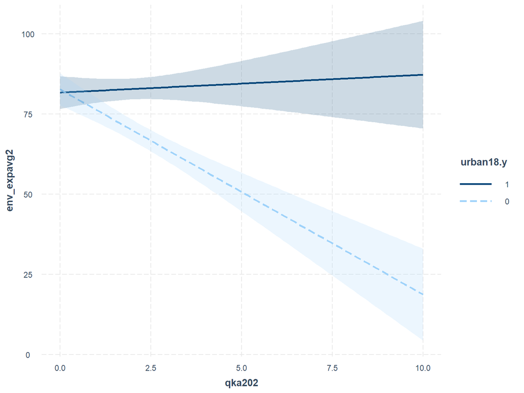

```r
interact_plot(my.lme4, pred = qka202, modx = urban18.y, interval = TRUE,
              int.width = 0.8)
```

### 20年：城乡的调节作用

```r
# print(df6$urban18.y)
my.lme2 <- lmer(env_expavg2_20 ~ qka202 +age +finc_corrected+fexp_corrected+urban18.y +qka202:urban18.y +(1|provcd18.r) ,data=df6,REML=F)
summary(my.lme2)
```

```
## Linear mixed model fit by maximum likelihood . t-tests use Satterthwaite's
##   method [lmerModLmerTest]
## Formula: env_expavg2_20 ~ qka202 + age + finc_corrected + fexp_corrected +
##     urban18.y + qka202:urban18.y + (1 | provcd18.r)
##    Data: df6
##
##      AIC      BIC   logLik deviance df.resid
## 110434.9 110499.3 -55208.5 110416.9     9453
##
## Scaled residuals:
##     Min      1Q  Median      3Q     Max
## -2.1779 -0.5144 -0.2393  0.2010 18.4702
##
## Random effects:
##  Groups     Name        Variance Std.Dev.
##  provcd18.r (Intercept)  265.9   16.31
##  Residual               6796.6   82.44
## Number of obs: 9462, groups:  provcd18.r, 55
##
## Fixed effects:
##                    Estimate Std. Error         df t value Pr(>|t|)
## (Intercept)       6.041e+01  5.113e+00  3.264e+02  11.815  < 2e-16 ***
## qka202           -4.812e+00  1.571e+00  9.462e+03  -3.062  0.00221 **
## age               3.297e-01  6.404e-02  9.404e+03   5.148 2.69e-07 ***
## finc_corrected    6.738e-05  1.364e-05  9.461e+03   4.938 8.01e-07 ***
## fexp_corrected    2.141e-05  1.566e-05  9.437e+03   1.367  0.17174
## urban18.y         4.492e+00  4.975e+00  9.461e+03   0.903  0.36659
## qka202:urban18.y  6.163e+00  2.277e+00  9.453e+03   2.707  0.00680 **
## ---
## Signif. codes:  0 '***' 0.001 '**' 0.01 '*' 0.05 '.' 0.1 ' ' 1
##
## Correlation of Fixed Effects:
##             (Intr) qka202 age    fnc_cr fxp_cr urb18.
## qka202      -0.534
## age         -0.431 -0.228
## finc_crrctd -0.138  0.020  0.078
## fexp_crrctd -0.060 -0.006  0.042 -0.545
## urban18.y   -0.481  0.620  0.023 -0.036 -0.019
## qk202:rb18.  0.433 -0.628 -0.021 -0.010  0.007 -0.930
## fit warnings:
## Some predictor variables are on very different scales: consider rescaling
```

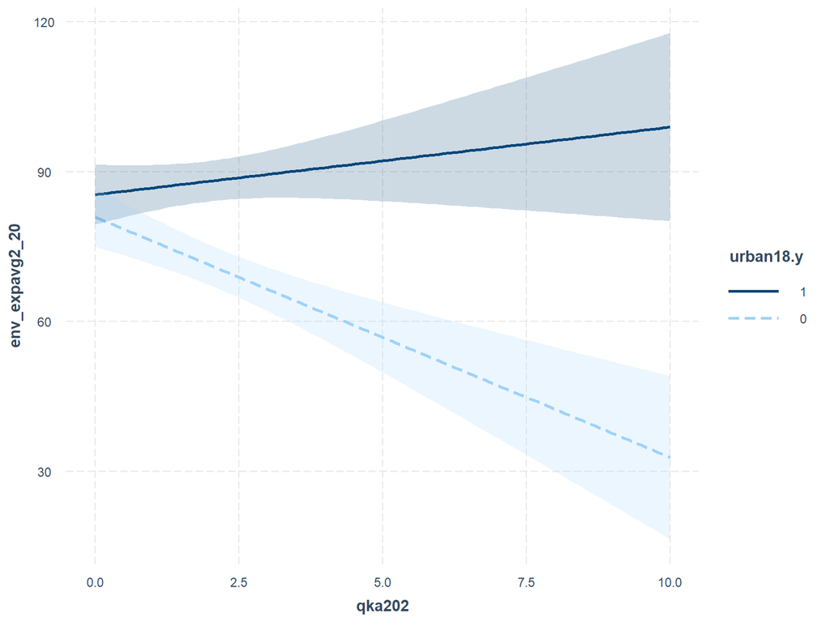

```r
interact_plot(my.lme2, pred = qka202, modx = urban18.y, interval = TRUE,
              int.width = 0.8)
```

```r
# df6$urban18.r <- dplyr::recode(df6$urban18.y, `1` = 0, `0` = 1)
# my.lme2 <- lmer(env_expavg2_20 ~ qka202 +age +finc_corrected+fexp_corrected+urban18.r +qka202:urban18.r +(1|provcd18.r) ,data=df6,REML=F)
# summary(my.lme2)
# interact_plot(my.lme2, pred = qka202, modx = urban18.r, interval = TRUE,
#               int.width = 0.8)
```

### 传统观念的解释

```r
attr(df_qme$qme202, "label")
```

```
## [1] "为了延续家族香火"
```

```r
my.lme3 <- lmer(env_expavg2_20 ~ qka202 +age +finc_corrected+fexp_corrected+qme202_20  +(1|provcd18.r) ,data=df6,REML=F)
summary(my.lme3)
```

```
## Linear mixed model fit by maximum likelihood . t-tests use Satterthwaite's
##   method [lmerModLmerTest]
## Formula: env_expavg2_20 ~ qka202 + age + finc_corrected + fexp_corrected +
##     qme202_20 + (1 | provcd18.r)
##    Data: df6
##
##      AIC      BIC   logLik deviance df.resid
## 108258.4 108315.5 -54121.2 108242.4     9265
##
## Scaled residuals:
##     Min      1Q  Median      3Q     Max
## -2.2739 -0.5172 -0.2433  0.2013 18.5470
##
## Random effects:
##  Groups     Name        Variance Std.Dev.
##  provcd18.r (Intercept)  307.4   17.53
##  Residual               6815.7   82.56
## Number of obs: 9273, groups:  provcd18.r, 55
##
## Fixed effects:
##                  Estimate Std. Error         df t value Pr(>|t|)
## (Intercept)     8.027e+01  6.039e+00  4.843e+02  13.290  < 2e-16 ***
## qka202         -3.099e+00  1.268e+00  9.235e+03  -2.443   0.0146 *
## age             4.113e-01  6.728e-02  9.229e+03   6.114 1.01e-09 ***
## finc_corrected  7.531e-05  1.373e-05  9.270e+03   5.486 4.23e-08 ***
## fexp_corrected  2.667e-05  1.578e-05  9.247e+03   1.690   0.0912 .
## qme202_20      -6.887e+00  1.538e+00  9.267e+03  -4.479 7.59e-06 ***
## ---
## Signif. codes:  0 '***' 0.001 '**' 0.01 '*' 0.05 '.' 0.1 ' ' 1
##
## Correlation of Fixed Effects:
##             (Intr) qka202 age    fnc_cr fxp_cr
## qka202      -0.228
## age         -0.253 -0.285
## finc_crrctd -0.183  0.035  0.067
## fexp_crrctd -0.083 -0.003  0.034 -0.549
## qme202_20   -0.630 -0.082 -0.174  0.065  0.038
## fit warnings:
## Some predictor variables are on very different scales: consider rescaling
```

```r
my.lme4 <- lmer(env_expavg2_20 ~ qka202 +age +finc_corrected+fexp_corrected+qme202_20 + qme202_20:qka202 +(1|provcd18.r) ,data=df6,REML=F)
summary(my.lme4)
```

```
## Linear mixed model fit by maximum likelihood . t-tests use Satterthwaite's
##   method [lmerModLmerTest]
## Formula: env_expavg2_20 ~ qka202 + age + finc_corrected + fexp_corrected +
##     qme202_20 + qme202_20:qka202 + (1 | provcd18.r)
##    Data: df6
##
##      AIC      BIC   logLik deviance df.resid
## 108256.5 108320.7 -54119.2 108238.5     9264
##
## Scaled residuals:
##     Min      1Q  Median      3Q     Max
## -2.2730 -0.5177 -0.2432  0.2039 18.5653
##
## Random effects:
##  Groups     Name        Variance Std.Dev.
##  provcd18.r (Intercept)  305.3   17.47
##  Residual               6813.0   82.54
## Number of obs: 9273, groups:  provcd18.r, 55
##
## Fixed effects:
##                    Estimate Std. Error         df t value Pr(>|t|)
## (Intercept)       1.012e+02  1.214e+01  4.579e+03   8.337  < 2e-16 ***
## qka202           -1.439e+01  5.826e+00  9.254e+03  -2.469 0.013553 *
## age               4.085e-01  6.728e-02  9.228e+03   6.072 1.32e-09 ***
## finc_corrected    7.547e-05  1.373e-05  9.270e+03   5.498 3.94e-08 ***
## fexp_corrected    2.685e-05  1.578e-05  9.247e+03   1.701 0.088942 .
## qme202_20        -1.395e+01  3.877e+00  9.253e+03  -3.599 0.000322 ***
## qka202:qme202_20  3.797e+00  1.913e+00  9.247e+03   1.985 0.047186 *
## ---
## Signif. codes:  0 '***' 0.001 '**' 0.01 '*' 0.05 '.' 0.1 ' ' 1
##
## Correlation of Fixed Effects:
##             (Intr) qka202 age    fnc_cr fxp_cr q202_2
## qka202      -0.872
## age         -0.145 -0.041
## finc_crrctd -0.087  0.003  0.067
## fexp_crrctd -0.036 -0.006  0.034 -0.549
## qme202_20   -0.921  0.889 -0.049  0.021  0.010
## q202:202_20  0.868 -0.976 -0.022  0.005  0.006 -0.918
## fit warnings:
## Some predictor variables are on very different scales: consider rescaling
```

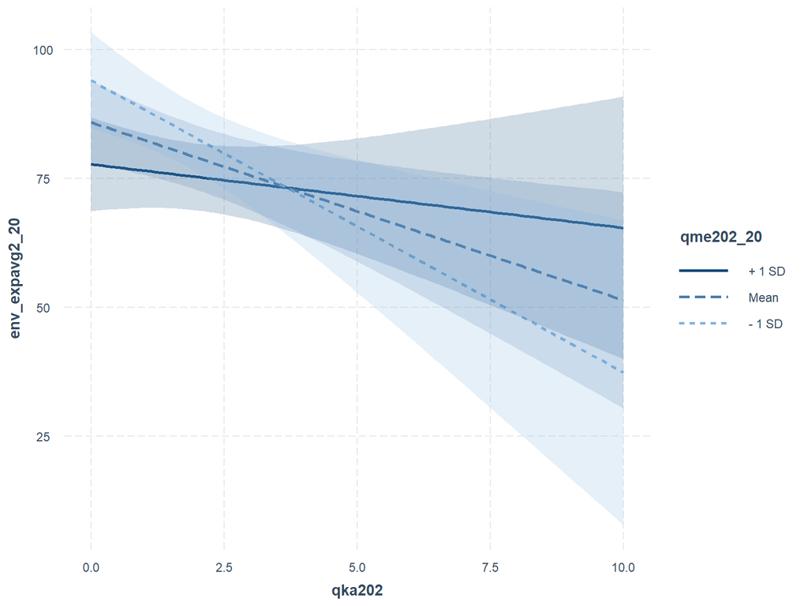

```r
interact_plot(my.lme4, pred = qka202, modx = qme202_20, interval = TRUE)
```

```r
my.lme5 <- lmer(env_expavg2_20 ~ qka202 +age +finc_corrected+fexp_corrected+qme202_20 + urban18.y + qme202_20:qka202 +qka202:urban18.y+qme202_20:urban18.y +(1|provcd18.r) ,data=df6,REML=F)
summary(my.lme5)
```

```
## Linear mixed model fit by maximum likelihood . t-tests use Satterthwaite's
##   method [lmerModLmerTest]
## Formula: env_expavg2_20 ~ qka202 + age + finc_corrected + fexp_corrected +
##     qme202_20 + urban18.y + qme202_20:qka202 + qka202:urban18.y +
##     qme202_20:urban18.y + (1 | provcd18.r)
##    Data: df6
##
##      AIC      BIC   logLik deviance df.resid
## 107065.2 107150.7 -53520.6 107041.2     9171
##
## Scaled residuals:
##     Min      1Q  Median      3Q     Max
## -2.1230 -0.5153 -0.2359  0.1964 18.6131
##
## Random effects:
##  Groups     Name        Variance Std.Dev.
##  provcd18.r (Intercept)  256.4   16.01
##  Residual               6708.2   81.90
## Number of obs: 9183, groups:  provcd18.r, 55
##
## Fixed effects:
##                       Estimate Std. Error         df t value Pr(>|t|)
## (Intercept)          1.127e+02  1.506e+01  7.104e+03   7.483 8.15e-14 ***
## qka202              -2.079e+01  6.360e+00  9.157e+03  -3.268  0.00109 **
## age                  4.229e-01  6.719e-02  9.115e+03   6.294 3.23e-10 ***
## finc_corrected       6.393e-05  1.375e-05  9.180e+03   4.649 3.38e-06 ***
## fexp_corrected       2.217e-05  1.569e-05  9.159e+03   1.413  0.15775
## qme202_20           -1.894e+01  4.715e+00  9.156e+03  -4.017 5.93e-05 ***
## urban18.y           -1.758e+01  1.014e+01  9.173e+03  -1.734  0.08296 .
## qka202:qme202_20     5.364e+00  1.997e+00  9.156e+03   2.686  0.00724 **
## qka202:urban18.y     6.954e+00  2.445e+00  9.173e+03   2.844  0.00447 **
## qme202_20:urban18.y  6.635e+00  3.128e+00  9.163e+03   2.121  0.03391 *
## ---
## Signif. codes:  0 '***' 0.001 '**' 0.01 '*' 0.05 '.' 0.1 ' ' 1
##
## Correlation of Fixed Effects:
##             (Intr) qka202 age    fnc_cr fxp_cr qm202_20 urb18. q202:2 q202:1
## qka202      -0.847
## age         -0.122 -0.031
## finc_crrctd -0.047 -0.003  0.070
## fexp_crrctd -0.022 -0.009  0.035 -0.541
## qme202_20   -0.937  0.829 -0.038  0.001  0.003
## urban18.y   -0.593  0.326  0.003 -0.040 -0.011  0.557
## q202:202_20  0.835 -0.967 -0.024  0.008  0.008 -0.867   -0.272
## qk202:rb18.  0.279 -0.347 -0.017 -0.003  0.001 -0.137   -0.409  0.197
## q202_20:18.  0.485 -0.167  0.003  0.022  0.006 -0.535   -0.854  0.192 -0.089
## fit warnings:
## Some predictor variables are on very different scales: consider rescaling
```

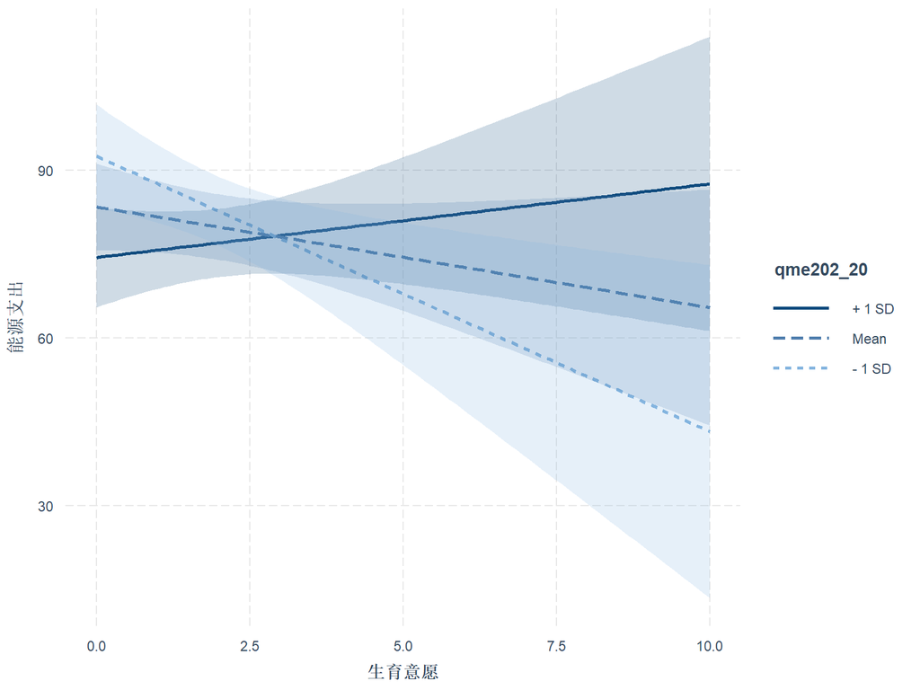

```r
interact_plot(my.lme5, pred = qka202, modx = qme202_20, interval = TRUE, x.label="生育意愿",y.label="能源支出",modx.labels = "传统观念")
```

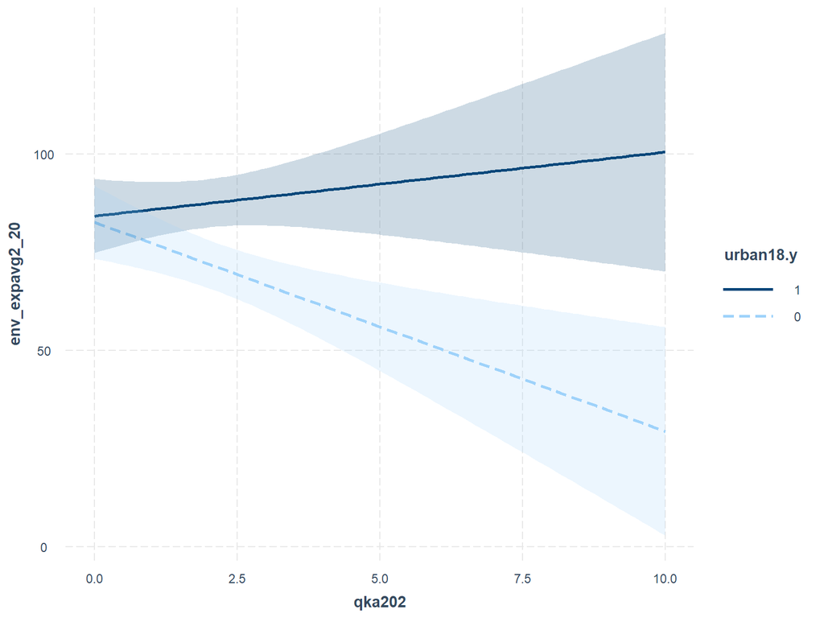

```r
interact_plot(my.lme5, pred = qka202, modx = urban18.y, interval = TRUE)
```

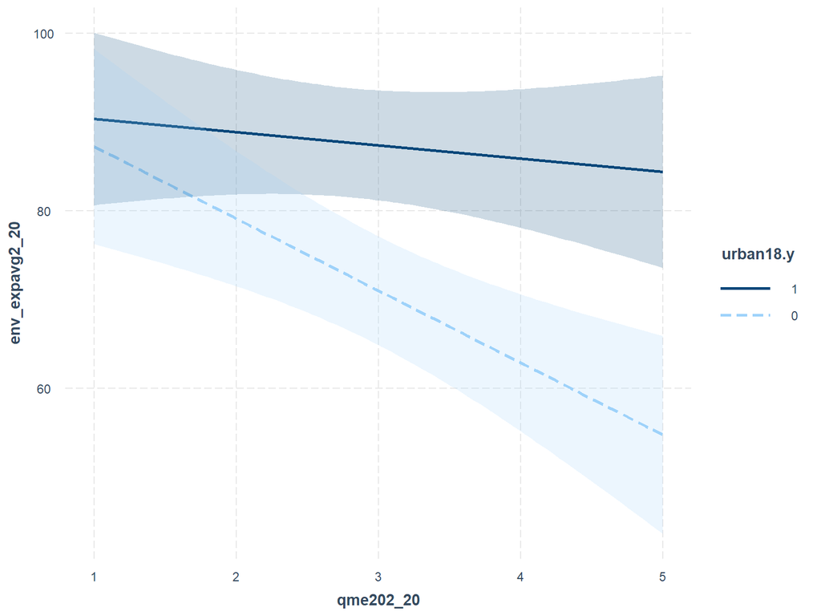

```r
interact_plot(my.lme5, pred = qme202_20, modx = urban18.y, interval = TRUE)
```

### 生育价值观的调节

```r
my.lme6 <- lmer(env_expavg2_20 ~ age +finc_corrected+fexp_corrected+(fermotiv1+fermotiv2+fermotiv3)*urban18.y*qka202  +(1|provcd18.r) ,data=df6,REML=F)
summary(my.lme6)
```

```
## Linear mixed model fit by maximum likelihood . t-tests use Satterthwaite's
##   method [lmerModLmerTest]
## Formula: env_expavg2_20 ~ age + finc_corrected + fexp_corrected + (fermotiv1 +
##     fermotiv2 + fermotiv3) * urban18.y * qka202 + (1 | provcd18.r)
##    Data: df6
##
##      AIC      BIC   logLik deviance df.resid
## 106841.8 106991.4 -53399.9 106799.8     9142
##
## Scaled residuals:
##     Min      1Q  Median      3Q     Max
## -2.1234 -0.5151 -0.2331  0.1955 18.6109
##
## Random effects:
##  Groups     Name        Variance Std.Dev.
##  provcd18.r (Intercept)  252     15.88
##  Residual               6702     81.87
## Number of obs: 9163, groups:  provcd18.r, 55
##
## Fixed effects:
##                              Estimate Std. Error         df t value Pr(>|t|)
## (Intercept)                 1.406e+02  3.040e+01  9.079e+03   4.625 3.79e-06
## age                         4.426e-01  6.895e-02  9.081e+03   6.419 1.44e-10
## finc_corrected              6.280e-05  1.377e-05  9.160e+03   4.559 5.20e-06
## fexp_corrected              2.066e-05  1.570e-05  9.140e+03   1.316 0.188114
## fermotiv1                  -3.794e+01  9.776e+00  9.143e+03  -3.881 0.000105
## fermotiv2                   8.318e+00  1.260e+01  9.135e+03   0.660 0.509342
## fermotiv3                   8.277e-01  1.328e+01  9.135e+03   0.062 0.950290
## urban18.y                  -3.970e+01  4.275e+01  9.140e+03  -0.929 0.353116
## qka202                     -2.952e+01  1.290e+01  9.140e+03  -2.288 0.022153
## fermotiv1:urban18.y         3.145e+01  1.207e+01  9.140e+03   2.606 0.009162
## fermotiv2:urban18.y        -4.676e+00  1.730e+01  9.139e+03  -0.270 0.786970
## fermotiv3:urban18.y        -1.220e+01  1.767e+01  9.136e+03  -0.690 0.490068
## fermotiv1:qka202            1.329e+01  4.517e+00  9.141e+03   2.943 0.003260
## fermotiv2:qka202           -7.524e+00  5.674e+00  9.136e+03  -1.326 0.184864
## fermotiv3:qka202            2.674e+00  5.901e+00  9.137e+03   0.453 0.650408
## urban18.y:qka202            2.205e+01  2.004e+01  9.140e+03   1.100 0.271166
## fermotiv1:urban18.y:qka202 -1.177e+01  5.802e+00  9.142e+03  -2.029 0.042531
## fermotiv2:urban18.y:qka202  3.900e+00  8.352e+00  9.143e+03   0.467 0.640517
## fermotiv3:urban18.y:qka202  2.602e+00  8.343e+00  9.140e+03   0.312 0.755118
##
## (Intercept)                ***
## age                        ***
## finc_corrected             ***
## fexp_corrected
## fermotiv1                  ***
## fermotiv2
## fermotiv3
## urban18.y
## qka202                     *
## fermotiv1:urban18.y        **
## fermotiv2:urban18.y
## fermotiv3:urban18.y
## fermotiv1:qka202           **
## fermotiv2:qka202
## fermotiv3:qka202
## urban18.y:qka202
## fermotiv1:urban18.y:qka202 *
## fermotiv2:urban18.y:qka202
## fermotiv3:urban18.y:qka202
## ---
## Signif. codes:  0 '***' 0.001 '**' 0.01 '*' 0.05 '.' 0.1 ' ' 1
```

```
##
## Correlation matrix not shown by default, as p = 19 > 12.
## Use print(value, correlation=TRUE)  or
##     vcov(value)        if you need it
```

```
## fit warnings:
## Some predictor variables are on very different scales: consider rescaling
```

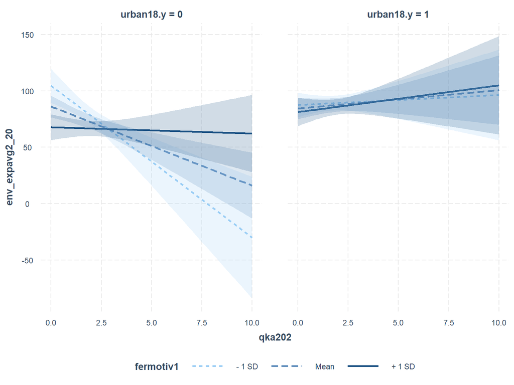

```r
interact_plot(my.lme6, pred = qka202, modx = fermotiv1, mod2=urban18.y, interval = TRUE)
```